# Lecture 3: Elegant Graphics with ggplot2

Xiao Guo

2023/3/4

# 3.1. Grammar of Graphics

## Hadley Wickham and R:ggplot2

### Chief scientist at RStudio, Creator of popular R packages: ggplot2, dplyr, tidyr, devtools, etc; “The man who r evolutionized R”.

### R graphics: base -> lattice -> ggplot2

- “ggplot2, started in 2005, is an attempt to take the good things about base and lattice graphics and improve on them with a strong underlying model” (Hadley Wickham).

### R:ggplot2 is one of most commonly downloaded R packages.

### Based on Grammar of Graphics by Wilkinson (2005; Springer 2ed).

[figure not shown]

## Grammar of Graphics (GG) (图形语法)

### Wilkinson(2005)创建了一套用来描述所有统计图形深层特性的语法规则，该语法回答了“什么是统计图形”这一问题。

### 一张统计图形就是从数据到**几何对象**(geometric object，缩写为geom，包括点、线、条形等)的**图形属性**(aesthetic object，缩写为aes，包括颜色、形状、大小等)的一个映射。此外，图形中还可能包含数据的**统计变换**(statistical transformation，缩写为stats)，最后绘制在某个特定的**坐标系**(coordinate system，缩写为coord)中，而**分面**(facet，指将数据绘图窗口划分为若干个子窗口)则可用来生成数据的不同子集的图形。

### 最基础的部分是你想要可视化的**数据**以及一系列将数据中的变量对应到图形属性的**映射**;

### **几何对象**代表在图中实际看到的图形元素，如点、线、多边形等；

### **统计变换**是对数据进行的某种汇总。例如，将数据分组计数以创建直方图；

### **标度**的作用是将数据的取值映射到图形空间。占线标度的常见做法是绘制图例和坐标轴；

### **坐标系**描述了数据如何映射到图形所在平面，它同时提供了看图所需的坐标轴和网格线；

### **分面**描述了如何将数据分解成各个子集，以及如何对子集作图并联合进行展示。分面也叫条件作图或网格作图。

## R:ggplot2 package

### The most popular package for producing static visualizations in R; New upgrade to Version 3.2.1; See CRAN for updated information.

### Online documentation at https://ggplot2.tidyverse.org/

### Download the useful cheatsheet created by Rstudio at https://github.com/rstudio/cheatsheets/blob/main/data-visualization.pdf

### Also available in Python.

## Base, Lattice and ggplot2 styles (first impression)

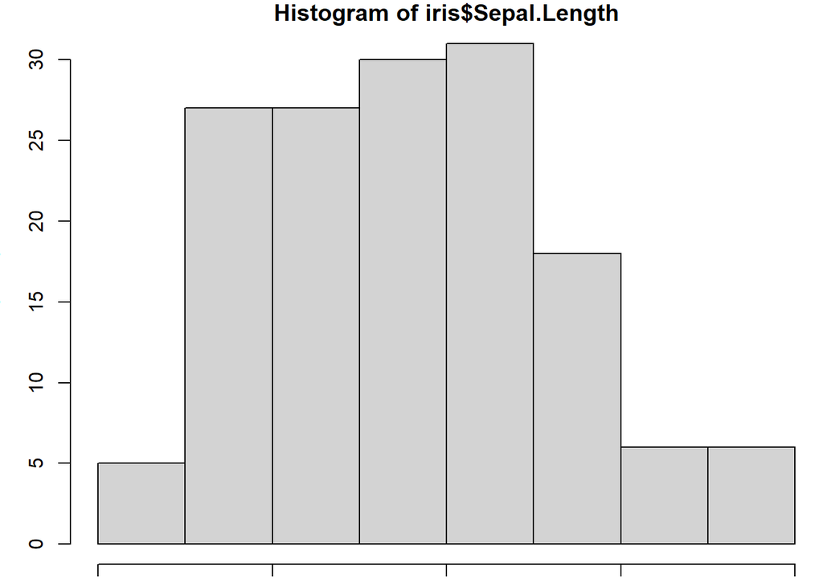

```r
par(mar=c(1,3,1,0))
hist(iris$Sepal.Length) # Base graphics
```

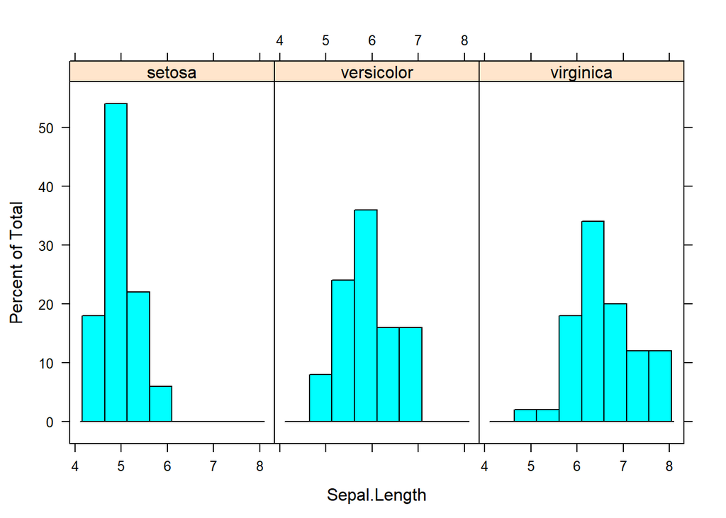

```r
library(lattice)
histogram(data=iris, ~Sepal.Length|Species)
```

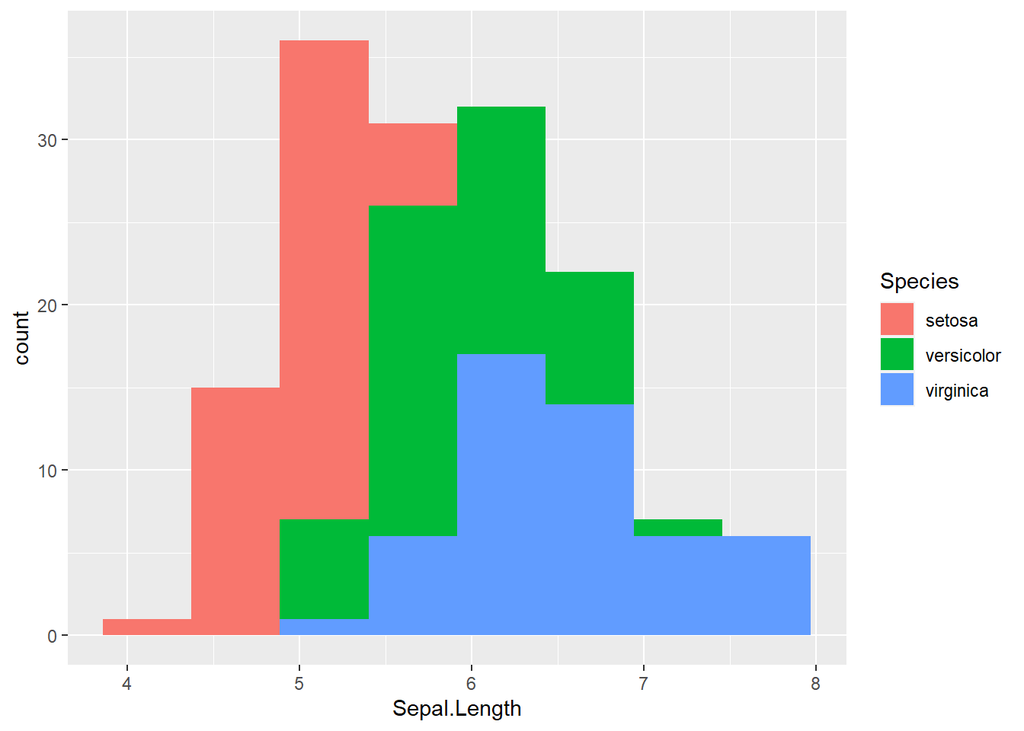

```r
library(ggplot2)
ggplot(data=iris,
       aes(x=Sepal.Length, fill=Species)) +
  geom_histogram(bins=8)
```

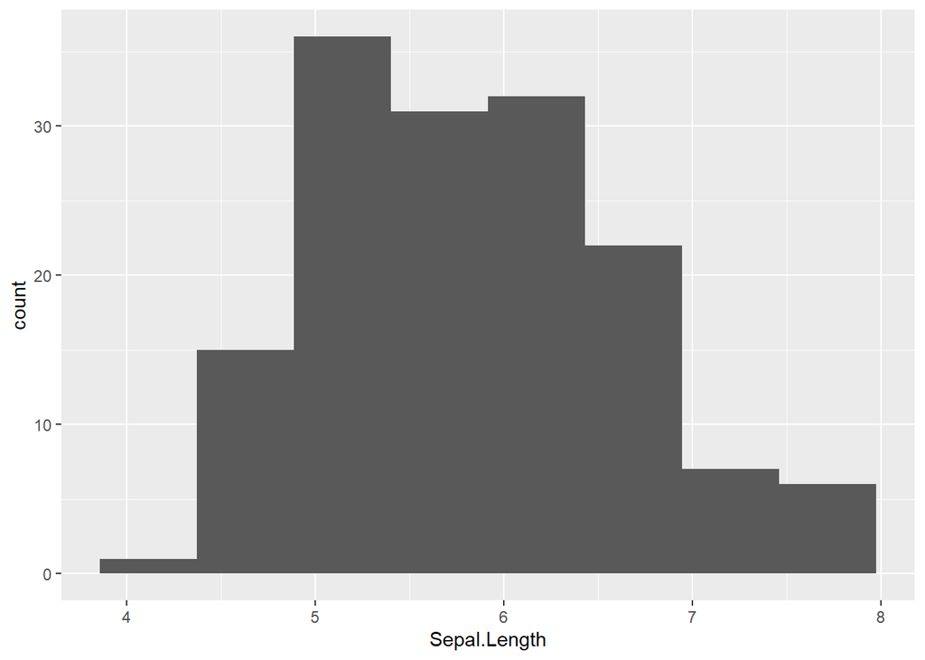

```r
library(ggplot2)
ggplot(data=iris,
       aes(x=Sepal.Length)) +
  geom_histogram(bins=8)
```

## You Will Learn …

### R:ggplot2 provides two ways/levels to build graphs:

#### qplot() - quick plot, supplies many defaults

#### ggplot() - grammar of graphics plot, with more controls

### Options and themes for making sophisticated ggplot2 graphs

### Later in this course, ggplot2 will also be used for animated/interactive plots

# 3.2 Quick plots with qplot()

### qplot() is analog to base plot(), where “q” means quick

### qplot() may create a quick plot with minimum typing

### It defines a plot in a single call with the basic syntax: `qplot(dataframe, variables, [geom], options)`

### Automatic use of default settings to make life easier

### A sensible geom will be picked by default if it is not supplied.

## Histogram

```r
library(gridExtra)
```

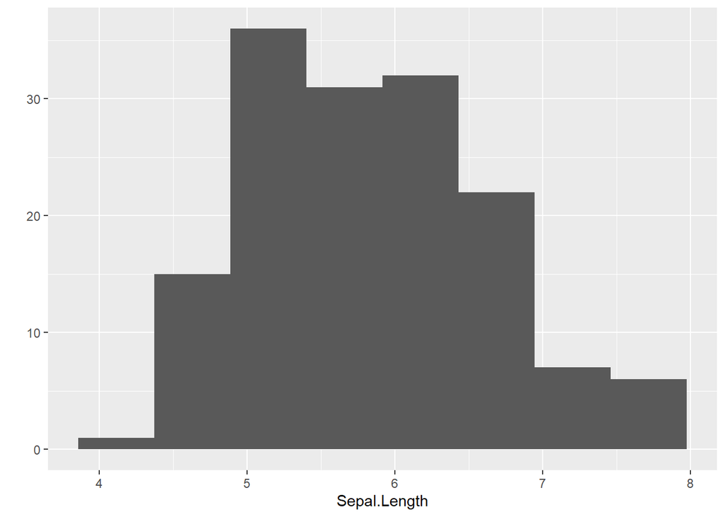

```r
qplot(data = iris, Sepal.Length, geom="histogram", bins = 8)
```

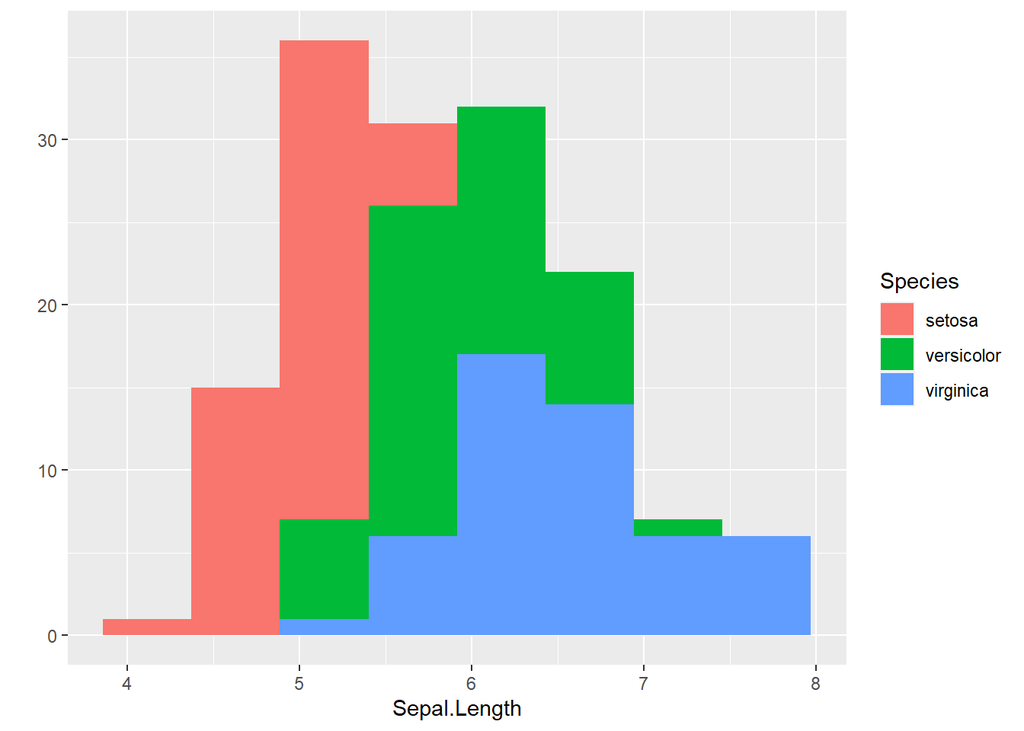

```r
qplot(data = iris, Sepal.Length, fill=Species, bins = 8)  # default geom
```

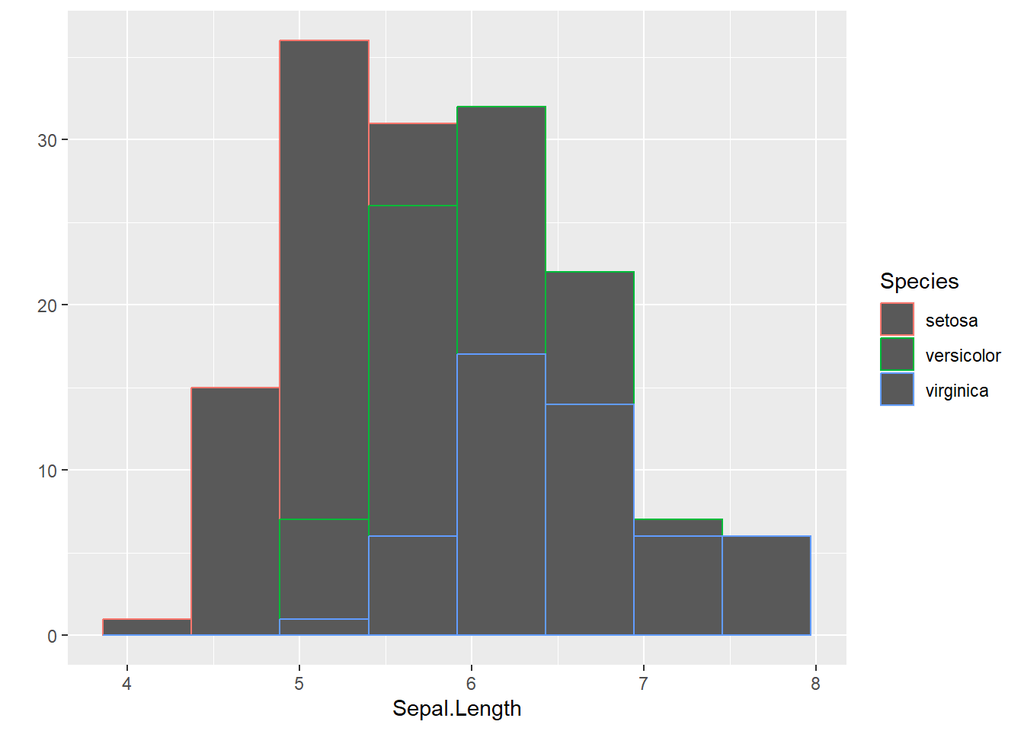

```r
qplot(data = iris, Sepal.Length, color=Species, bins = 8)
```

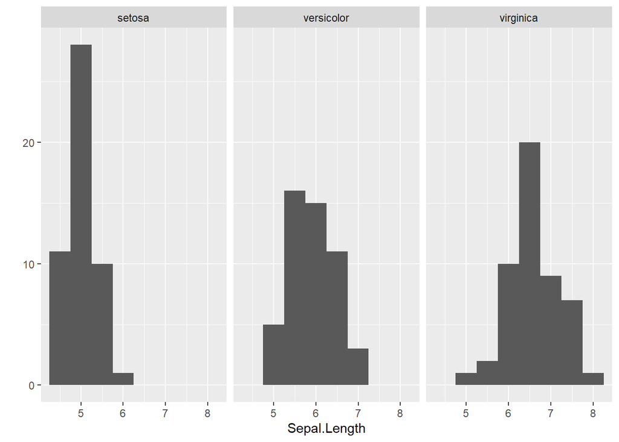

```r
qplot(data = iris, Sepal.Length, facets = .~Species, binwidth = 0.5)
```

```r
# grid.arrange(p1,p2,p3, ncol=3)
```

### Automatic color setting (color/fill are grouping variables in ggplot2)

### Faceting is similar to the conditioning function in Lattice

## Density plot

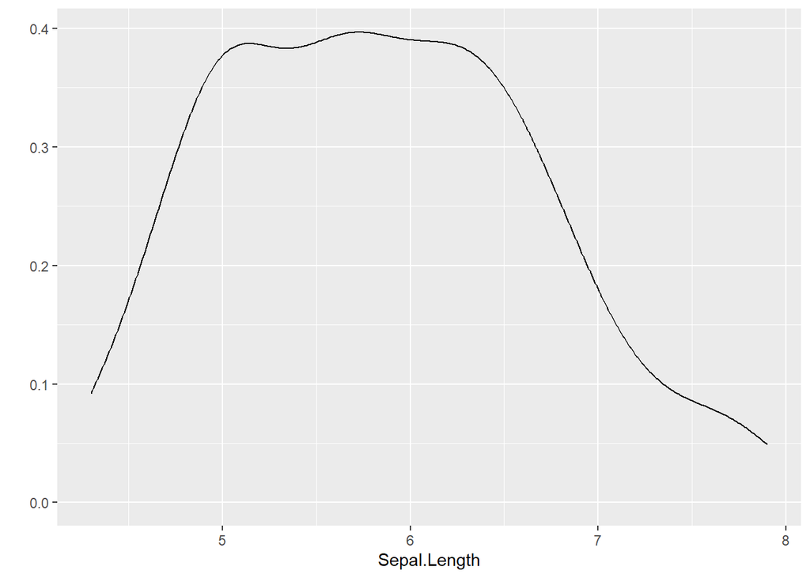

```r
qplot(data = iris, Sepal.Length, geom = "density")
```

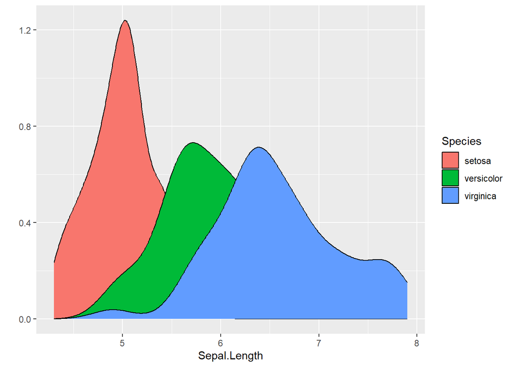

```r
qplot(data = iris, Sepal.Length, geom = "density",  fill = Species)
```

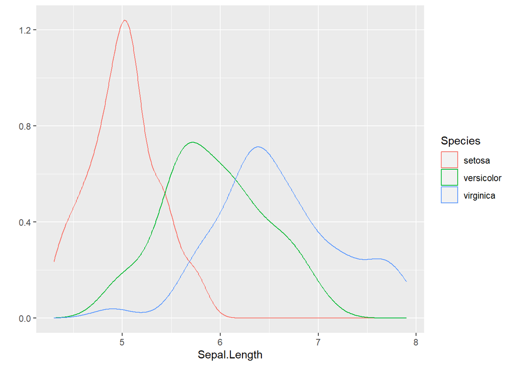

```r
qplot(data = iris, Sepal.Length, geom = "density",  color = Species)
```

## Boxplot with Grouping

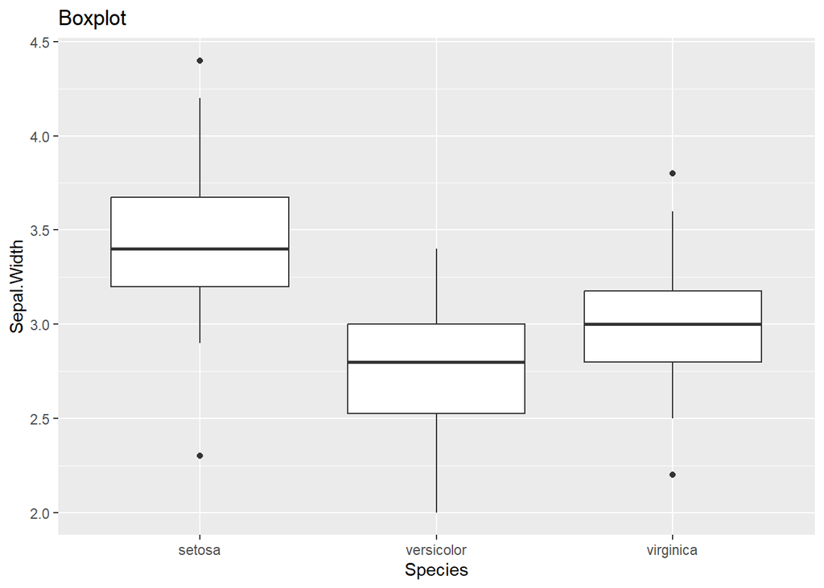

```r
qplot(data = iris, Species, Sepal.Width, geom="boxplot", main="Boxplot")
```

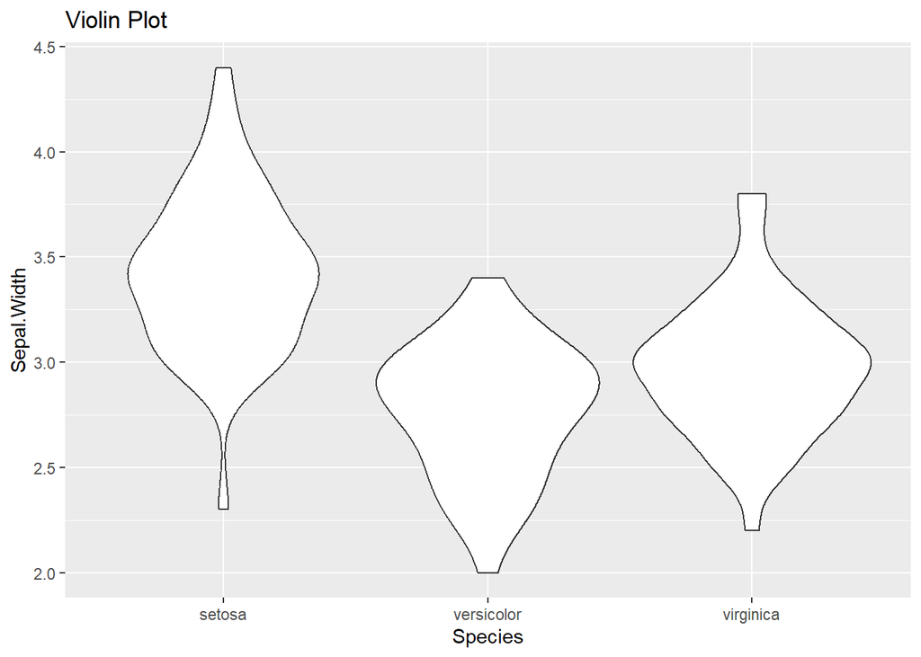

```r
qplot(data = iris, Species, Sepal.Width, geom="violin", main="Violin Plot")
```

### Following data are x (grouping) and y (response) variables

## Bar plot for categoricla variables

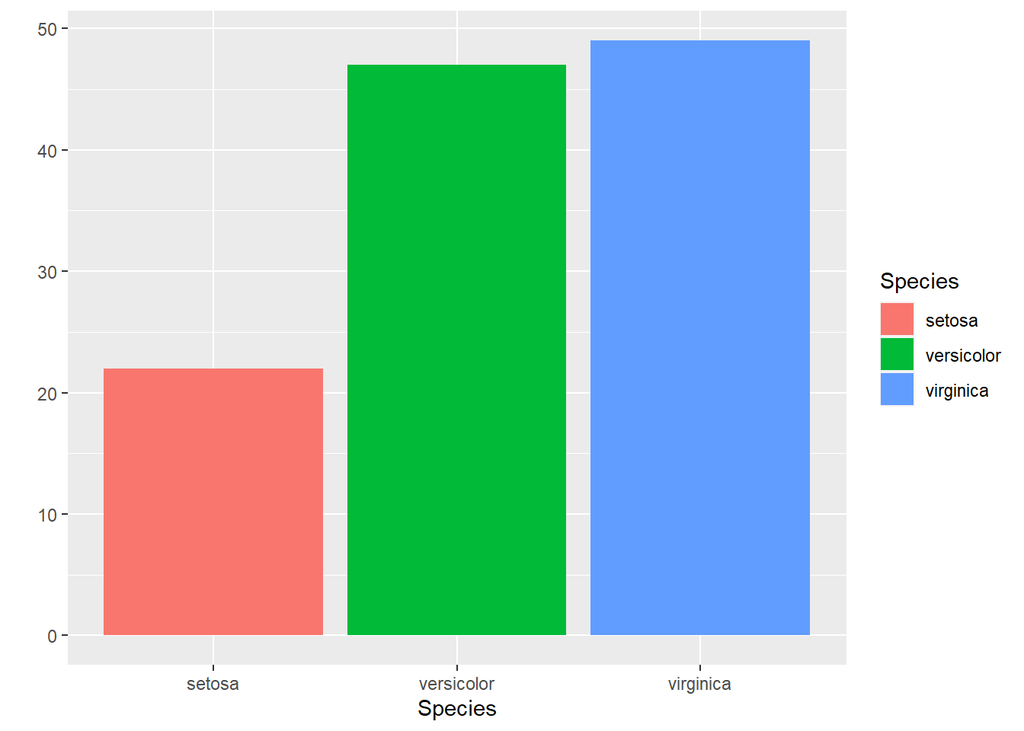

```r
qplot(data = subset(iris, Sepal.Length>5), Species, geom="bar",  fill=Species)
```